# CS 210 PROJECT

```python
import pandas as pd
import numpy as np
import matplotlib.pyplot as plt
import seaborn as sns
import bs4
import requests


from selenium.webdriver import Safari
from selenium import webdriver
from selenium.webdriver.support.ui import WebDriverWait
from selenium.webdriver.common.keys import Keys
from selenium.common.exceptions import TimeoutException, NoSuchElementException
import time
from selenium.webdriver.common.by import By
```

```python
driver = Safari()
driver.get("file:///Users/korhanerdogdu/Desktop/dersmateryali(cs210)/instagram-korhanerdd-2023-12-08-StzEaYve/ads_and_topics/posts_viewed.html")
```

# 1) Accounts Viewed

```python
table = driver.find_element(By.XPATH, '/html/body/div/div/div/div[2]/div[2]')

rows = table.find_elements(By.TAG_NAME, 'div')
```

SCRAPING THE DATA

```python
tableData = []


for row in rows:

    infos = row.find_elements(By.TAG_NAME, "tr")  # all tr's in one row


    rowData = []

    for info in infos:  # each tr in all row

        div_inside_tr = info.find_element(By.TAG_NAME, "div")
        div_text = div_inside_tr.text

        rowData.append(div_text)



    if(rowData != []):
        tableData.append(rowData)



#for row in tableData:
    #print(row)
```

```python
unique_tableData = []

for entry in tableData:
    if entry not in unique_tableData:
        unique_tableData.append(entry)

# Print the unique entries
#for entry in unique_tableData:
    #print(entry)
```

```python
split_data = []

for entry in unique_tableData:
    author = entry[0]
    date_time = entry[1].split(', ')
    date = date_time[0] + ', ' + date_time[1]
    time = date_time[2]
    split_data.append([author, date, time])
```

```python
accounts_viewed_dataframe = pd.DataFrame(split_data, columns=['Account name', 'Date','Time'])
accounts_viewed_dataframe.head(5)
```

|  | Account name | Date | Time |
| --- | --- | --- | --- |
| 0 | ulaslafforgue | Nov 30, 2023 | 4:02 PM |
| 1 | euroleague | Nov 30, 2023 | 4:02 PM |
| 2 | 1soru.1cevap | Nov 30, 2023 | 4:02 PM |
| 3 | fbbasketbol | Nov 30, 2023 | 4:02 PM |
| 4 | norwaytravelers | Nov 30, 2023 | 4:02 PM |

```python
accounts_viewed_dataframe
```

|  | Account name | Date | Time |
| --- | --- | --- | --- |
| 0 | ulaslafforgue | Nov 30, 2023 | 4:02 PM |
| 1 | euroleague | Nov 30, 2023 | 4:02 PM |
| 2 | 1soru.1cevap | Nov 30, 2023 | 4:02 PM |
| 3 | fbbasketbol | Nov 30, 2023 | 4:02 PM |
| 4 | norwaytravelers | Nov 30, 2023 | 4:02 PM |
| ... | ... | ... | ... |
| 465 | guclu_motivasyon | Dec 7, 2023 | 10:32 AM |
| 466 | trace.young | Dec 7, 2023 | 12:01 PM |
| 467 | houseofhighlights | Dec 7, 2023 | 12:11 PM |
| 468 | tatemcrae | Dec 7, 2023 | 2:23 PM |
| 469 | 1soru.1cevap | Dec 7, 2023 | 3:40 PM |

470 rows × 3 columns

GENERAL INFORMATIN ABOUT DATASET

```python
accounts_viewed_dataframe.info()
```

```
<class 'pandas.core.frame.DataFrame'>
RangeIndex: 470 entries, 0 to 469
Data columns (total 3 columns):
 #   Column        Non-Null Count  Dtype
---  ------        --------------  -----
 0   Account name  470 non-null    object
 1   Date          470 non-null    object
 2   Time          470 non-null    object
dtypes: object(3)
memory usage: 11.1+ KB
```

DESCRIBING THE DATASET

```python
accounts_viewed_dataframe.describe()
```

|  | Account name | Date | Time |
| --- | --- | --- | --- |
| count | 470 | 470 | 470 |
| unique | 105 | 9 | 218 |
| top | 1soru.1cevap | Dec 6, 2023 | 12:55 PM |
| freq | 41 | 95 | 8 |

MOST VIEWED ACCOUNTS

```python
accounts = accounts_viewed_dataframe['Account name'].value_counts().head()
accounts
```

```
1soru.1cevap       41
fbbasketbol        35
ogrencikariyeri    21
1907basketbol      20
euroleague         17
Name: Account name, dtype: int64
```

GETTING A SPECIFIC ACCOUNT DATA

```python
filtered_acc_name = accounts_viewed_dataframe[accounts_viewed_dataframe['Account name'] == 'fbbasketbol']
filtered_acc_name
```

|  | Account name | Date | Time |
| --- | --- | --- | --- |
| 3 | fbbasketbol | Nov 30, 2023 | 4:02 PM |
| 16 | fbbasketbol | Nov 30, 2023 | 11:46 PM |
| 20 | fbbasketbol | Nov 30, 2023 | 11:49 PM |
| 24 | fbbasketbol | Nov 30, 2023 | 11:51 PM |
| 29 | fbbasketbol | Dec 1, 2023 | 5:53 AM |
| 55 | fbbasketbol | Dec 2, 2023 | 1:39 AM |
| 66 | fbbasketbol | Dec 2, 2023 | 11:25 AM |
| 68 | fbbasketbol | Dec 2, 2023 | 11:45 AM |
| 74 | fbbasketbol | Dec 3, 2023 | 2:23 AM |
| 108 | fbbasketbol | Dec 4, 2023 | 7:57 AM |
| 155 | fbbasketbol | Dec 5, 2023 | 12:55 PM |
| 172 | fbbasketbol | Dec 6, 2023 | 12:54 AM |
| 193 | fbbasketbol | Dec 6, 2023 | 9:51 AM |
| 194 | fbbasketbol | Dec 6, 2023 | 10:49 AM |
| 195 | fbbasketbol | Dec 6, 2023 | 11:09 AM |
| 201 | fbbasketbol | Dec 6, 2023 | 12:25 PM |
| 203 | fbbasketbol | Dec 6, 2023 | 12:38 PM |
| 218 | fbbasketbol | Dec 6, 2023 | 10:30 PM |
| 241 | fbbasketbol | Dec 7, 2023 | 6:02 AM |
| 243 | fbbasketbol | Dec 7, 2023 | 6:41 AM |
| 283 | fbbasketbol | Nov 30, 2023 | 11:50 PM |
| 284 | fbbasketbol | Nov 30, 2023 | 11:54 PM |
| 289 | fbbasketbol | Dec 1, 2023 | 5:54 AM |
| 308 | fbbasketbol | Dec 2, 2023 | 2:28 AM |
| 317 | fbbasketbol | Dec 2, 2023 | 11:31 AM |
| 318 | fbbasketbol | Dec 2, 2023 | 12:38 PM |
| 325 | fbbasketbol | Dec 3, 2023 | 2:36 AM |
| 353 | fbbasketbol | Dec 4, 2023 | 8:00 AM |
| 411 | fbbasketbol | Dec 6, 2023 | 10:08 AM |
| 412 | fbbasketbol | Dec 6, 2023 | 11:19 AM |
| 417 | fbbasketbol | Dec 6, 2023 | 12:29 PM |
| 418 | fbbasketbol | Dec 6, 2023 | 12:42 PM |
| 431 | fbbasketbol | Dec 6, 2023 | 11:19 PM |
| 448 | fbbasketbol | Dec 7, 2023 | 6:40 AM |
| 450 | fbbasketbol | Dec 7, 2023 | 6:44 AM |

DISPLAYING SPECIFIC ACCOUNT WHICH GIVES INFO ABOUT THE TIME, DATE AND AMOUNT WHEN I INTERACTED WITH ITS POST

```python
filtered_acc_name.value_counts()
```

```
Account name  Date          Time
fbbasketbol   Dec 1, 2023   5:53 AM     1
              Dec 7, 2023   6:40 AM     1
              Dec 6, 2023   12:29 PM    1
                            12:38 PM    1
                            12:42 PM    1
                            12:54 AM    1
                            9:51 AM     1
              Dec 7, 2023   6:02 AM     1
                            6:41 AM     1
              Dec 6, 2023   11:19 PM    1
              Dec 7, 2023   6:44 AM     1
              Nov 30, 2023  11:46 PM    1
                            11:49 PM    1
                            11:50 PM    1
                            11:51 PM    1
                            11:54 PM    1
              Dec 6, 2023   12:25 PM    1
                            11:19 AM    1
              Dec 1, 2023   5:54 AM     1
              Dec 3, 2023   2:23 AM     1
              Dec 2, 2023   11:25 AM    1
                            11:31 AM    1
                            11:45 AM    1
                            12:38 PM    1
                            1:39 AM     1
                            2:28 AM     1
              Dec 3, 2023   2:36 AM     1
              Dec 6, 2023   11:09 AM    1
              Dec 4, 2023   7:57 AM     1
                            8:00 AM     1
              Dec 5, 2023   12:55 PM    1
              Dec 6, 2023   10:08 AM    1
                            10:30 PM    1
                            10:49 AM    1
              Nov 30, 2023  4:02 PM     1
dtype: int64
```

FOR EACH ACCOUNT, TOTAL NUMBER OF INTERACTIONS

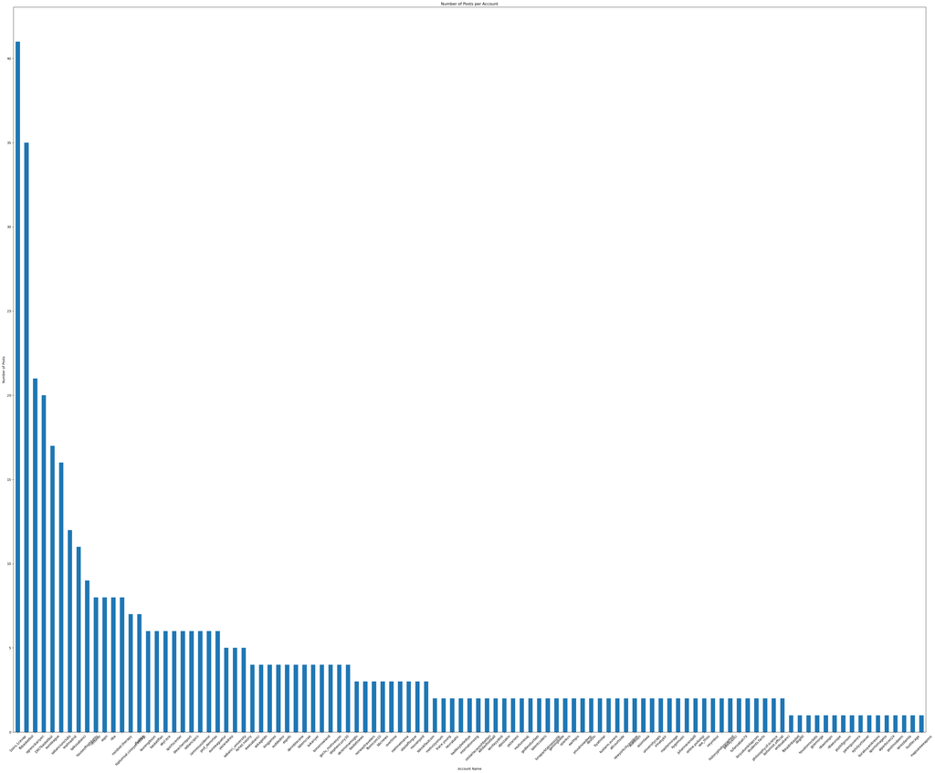

```python
# Count the number of posts per account
post_counts = accounts_viewed_dataframe['Account name'].value_counts()

# Plot the data
plt.figure(figsize=(50, 40))
post_counts.plot(kind='bar')  # You can use 'barh' for a horizontal bar chart
plt.title('Number of Posts per Account')
plt.xlabel('Account Name')
plt.ylabel('Number of Posts')
plt.xticks(rotation=45)  # Rotate the x labels if they are too crowded
plt.show()
```

THE AMOUNT OF POSTS THAT I INTERACTED GIVEN A SPECIFIC DAY

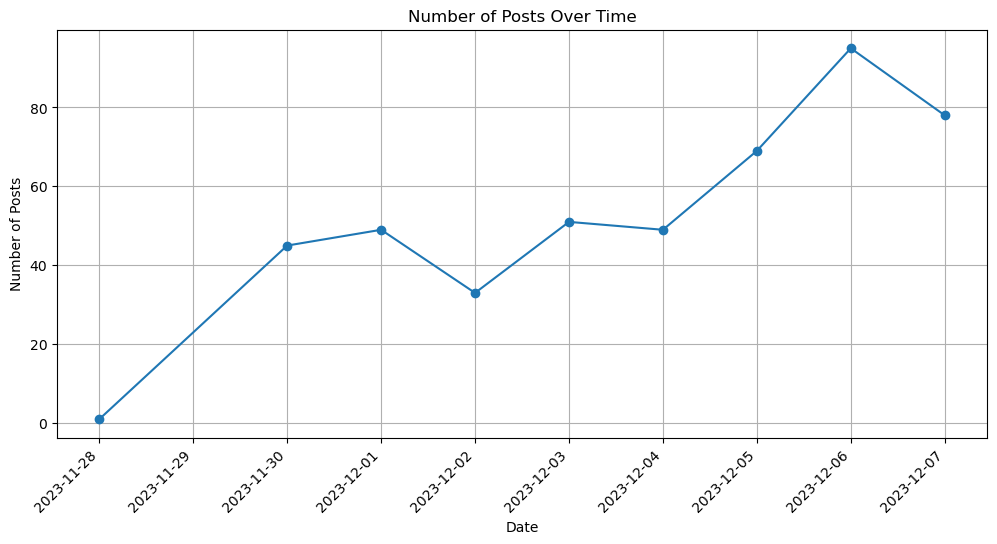

```python
accounts_viewed_dataframe['Date'] = pd.to_datetime(accounts_viewed_dataframe['Date'])

# Count the number of posts per day
posts_per_day = accounts_viewed_dataframe.groupby(accounts_viewed_dataframe['Date']).size()

# Plot the data
plt.figure(figsize=(12, 6))
posts_per_day.plot(kind='line', marker='o')  # Line chart with circle markers
plt.title('Number of Posts Over Time')
plt.xlabel('Date')
plt.ylabel('Number of Posts')
plt.xticks(rotation=45)  # Rotate the x labels for better readability
plt.grid(True)
plt.show()
```

```python
accounts_viewed_dataframe
```

|  | Account name | Date | Time |
| --- | --- | --- | --- |
| 0 | ulaslafforgue | 2023-11-30 | 4:02 PM |
| 1 | euroleague | 2023-11-30 | 4:02 PM |
| 2 | 1soru.1cevap | 2023-11-30 | 4:02 PM |
| 3 | fbbasketbol | 2023-11-30 | 4:02 PM |
| 4 | norwaytravelers | 2023-11-30 | 4:02 PM |
| ... | ... | ... | ... |
| 465 | guclu_motivasyon | 2023-12-07 | 10:32 AM |
| 466 | trace.young | 2023-12-07 | 12:01 PM |
| 467 | houseofhighlights | 2023-12-07 | 12:11 PM |
| 468 | tatemcrae | 2023-12-07 | 2:23 PM |
| 469 | 1soru.1cevap | 2023-12-07 | 3:40 PM |

470 rows × 3 columns

THE AMOUNT OF POSTS THAT I INTERACTED GIVEN A SPECIFIC HOUR OF A DAY

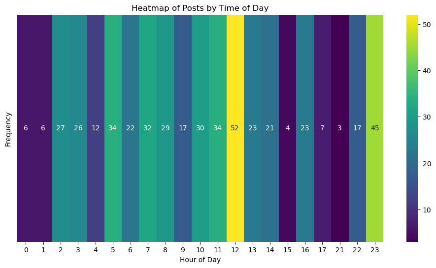

```python
# Convert 'Time' to datetime and extract the hour
accounts_viewed_dataframe['Hour'] = pd.to_datetime(accounts_viewed_dataframe['Time']).dt.hour

# Count the number of posts per hour
hourly_counts = accounts_viewed_dataframe['Hour'].value_counts().sort_index()

# Create a DataFrame for the heatmap
heatmap_data = pd.DataFrame(hourly_counts).T

# Create the heatmap
plt.figure(figsize=(12, 6))
sns.heatmap(heatmap_data, annot=True, cmap='viridis')
plt.title('Heatmap of Posts by Time of Day')
plt.xlabel('Hour of Day')
plt.ylabel('Frequency')
plt.yticks([])  # Hide the y-axis labels as there's only one row
plt.show()
```

POST FREQUENCY BY HOUR AND DATE

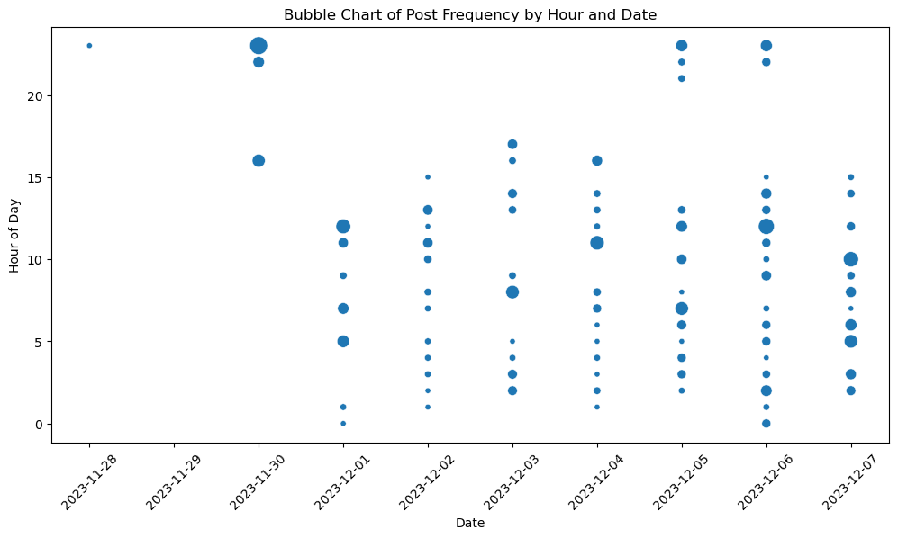

```python
# Group by Hour and Date and count posts
grouped = accounts_viewed_dataframe.groupby(['Hour', accounts_viewed_dataframe['Date'].dt.date]).size().reset_index(name='counts')

# Plotting
plt.figure(figsize=(12, 6))
sns.scatterplot(data=grouped, x='Date', y='Hour', size='counts', legend=False, sizes=(20, 200))
plt.title('Bubble Chart of Post Frequency by Hour and Date')
plt.xlabel('Date')
plt.ylabel('Hour of Day')
plt.xticks(rotation=45)
plt.show()
```

DISTRIBUTION OF POSTS

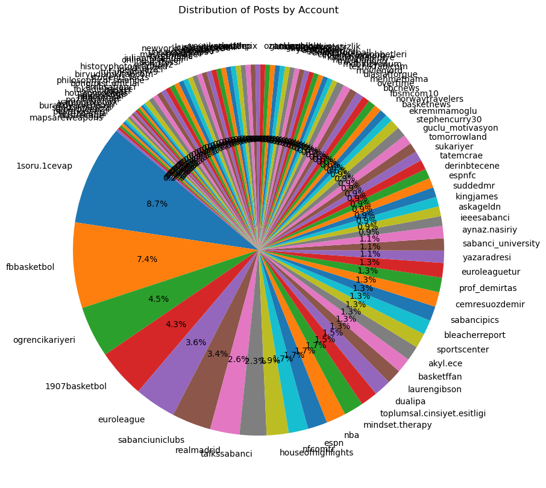

```python
# Count the number of posts for each account
account_post_counts = accounts_viewed_dataframe['Account name'].value_counts()

# Plot the data in a pie chart
plt.figure(figsize=(300, 10))
account_post_counts.plot(kind='pie', autopct='%1.1f%%', startangle=140)
plt.title('Distribution of Posts by Account')
plt.ylabel('')  # Hide the y-label
plt.show()
```

FOR SORTING #For ascending order sorted_df = accounts_viewed_dataframe.sort_values(by='Date') #For descending order sorted_df = accounts_viewed_dataframe.sort_values(by='Date', ascending=False)

```python
accounts_viewed_dataframe
```

|  | Account name | Date | Time | Hour |
| --- | --- | --- | --- | --- |
| 0 | ulaslafforgue | 2023-11-30 | 4:02 PM | 16 |
| 1 | euroleague | 2023-11-30 | 4:02 PM | 16 |
| 2 | 1soru.1cevap | 2023-11-30 | 4:02 PM | 16 |
| 3 | fbbasketbol | 2023-11-30 | 4:02 PM | 16 |
| 4 | norwaytravelers | 2023-11-30 | 4:02 PM | 16 |
| ... | ... | ... | ... | ... |
| 465 | guclu_motivasyon | 2023-12-07 | 10:32 AM | 10 |
| 466 | trace.young | 2023-12-07 | 12:01 PM | 12 |
| 467 | houseofhighlights | 2023-12-07 | 12:11 PM | 12 |
| 468 | tatemcrae | 2023-12-07 | 2:23 PM | 14 |
| 469 | 1soru.1cevap | 2023-12-07 | 3:40 PM | 15 |

470 rows × 4 columns

```python
saffetyy = accounts_viewed_dataframe.copy()
saffetyy
```

|  | Account name | Date | Time | Hour |
| --- | --- | --- | --- | --- |
| 0 | ulaslafforgue | 2023-11-30 | 4:02 PM | 16 |
| 1 | euroleague | 2023-11-30 | 4:02 PM | 16 |
| 2 | 1soru.1cevap | 2023-11-30 | 4:02 PM | 16 |
| 3 | fbbasketbol | 2023-11-30 | 4:02 PM | 16 |
| 4 | norwaytravelers | 2023-11-30 | 4:02 PM | 16 |
| ... | ... | ... | ... | ... |
| 465 | guclu_motivasyon | 2023-12-07 | 10:32 AM | 10 |
| 466 | trace.young | 2023-12-07 | 12:01 PM | 12 |
| 467 | houseofhighlights | 2023-12-07 | 12:11 PM | 12 |
| 468 | tatemcrae | 2023-12-07 | 2:23 PM | 14 |
| 469 | 1soru.1cevap | 2023-12-07 | 3:40 PM | 15 |

470 rows × 4 columns

STARTING MACHINE LEARNING METHODS

```python
import pandas as pd
from sklearn.model_selection import train_test_split
from sklearn.preprocessing import LabelEncoder

from sklearn.tree import DecisionTreeClassifier

from sklearn.metrics import classification_report, confusion_matrix
```

1. Data Preprocessing

WE WILL TRY TO PREDICT THE ACCOUNT NAMES FROM THE OTHER COOLUMN DATAS THAT WE HAVE

```python
# Convert 'Date' to datetime and extract features
accounts_viewed_dataframe['Date'] = pd.to_datetime(accounts_viewed_dataframe['Date'])
accounts_viewed_dataframe['DayOfWeek'] = accounts_viewed_dataframe['Date'].dt.dayofweek  # Monday=0, Sunday=6
accounts_viewed_dataframe['Day'] = accounts_viewed_dataframe['Date'].dt.day
accounts_viewed_dataframe['Month'] = accounts_viewed_dataframe['Date'].dt.month
accounts_viewed_dataframe['Year'] = accounts_viewed_dataframe['Date'].dt.year

# Encode 'Account name' into numerical values
label_encoder = LabelEncoder()
accounts_viewed_dataframe['Account name'] = label_encoder.fit_transform(accounts_viewed_dataframe['Account name'])

# Define your features and target variable
X = accounts_viewed_dataframe[['Hour', 'DayOfWeek', 'Day', 'Month', 'Year']]  # Features
y = accounts_viewed_dataframe['Account name']  # Target variable
```

```python
accounts_viewed_dataframe
```

|  | Account name | Date | Time | Hour | DayOfWeek | Day | Month | Year |
| --- | --- | --- | --- | --- | --- | --- | --- | --- |
| 0 | 99 | 2023-11-30 | 4:02 PM | 16 | 3 | 30 | 11 | 2023 |
| 1 | 28 | 2023-11-30 | 4:02 PM | 16 | 3 | 30 | 11 | 2023 |
| 2 | 1 | 2023-11-30 | 4:02 PM | 16 | 3 | 30 | 11 | 2023 |
| 3 | 31 | 2023-11-30 | 4:02 PM | 16 | 3 | 30 | 11 | 2023 |
| 4 | 67 | 2023-11-30 | 4:02 PM | 16 | 3 | 30 | 11 | 2023 |
| ... | ... | ... | ... | ... | ... | ... | ... | ... |
| 465 | 37 | 2023-12-07 | 10:32 AM | 10 | 3 | 7 | 12 | 2023 |
| 466 | 97 | 2023-12-07 | 12:01 PM | 12 | 3 | 7 | 12 | 2023 |
| 467 | 39 | 2023-12-07 | 12:11 PM | 12 | 3 | 7 | 12 | 2023 |
| 468 | 92 | 2023-12-07 | 2:23 PM | 14 | 3 | 7 | 12 | 2023 |
| 469 | 1 | 2023-12-07 | 3:40 PM | 15 | 3 | 7 | 12 | 2023 |

470 rows × 8 columns

1. Splitting the Dataset

```python
X_train, X_test, y_train, y_test = train_test_split(X, y, test_size=0.2, random_state=42)
```

1. Model Selection

```python
model = DecisionTreeClassifier()
```

1. Training the Model

```python
model.fit(X_train, y_train)
```

```
DecisionTreeClassifier()
```

1. Model Evaluation

```python
# Making predictions
y_pred = model.predict(X_test)
```

```python
from sklearn.metrics import accuracy_score
accuracy = accuracy_score(y_test, y_pred)
print(f'Accuracy: {accuracy * 100}%')
```

```
Accuracy: 11.702127659574469%
```

```python
cm = confusion_matrix(y_test, y_pred)
```

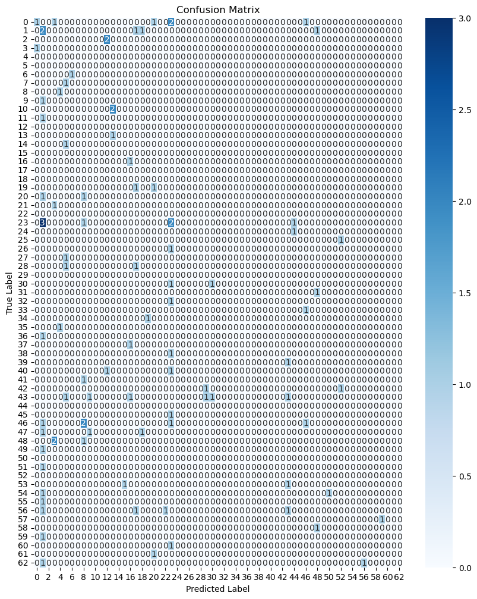

```python
# Plotting the confusion matrix
plt.figure(figsize=(10, 12))
sns.heatmap(cm, annot=True, fmt='g', cmap='Blues')
plt.title('Confusion Matrix')
plt.xlabel('Predicted Label')
plt.ylabel('True Label')
plt.show()
```

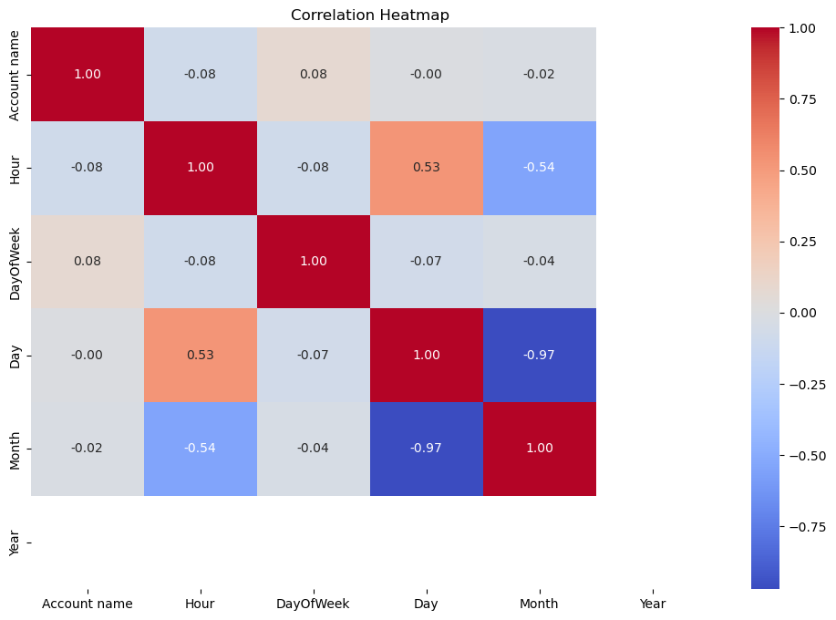

```python
correlations = accounts_viewed_dataframe.corr()

# Plotting the results in a heatmap
plt.figure(figsize=(12, 8))
sns.heatmap(correlations, annot=True, cmap='coolwarm', fmt=".2f")
plt.title('Correlation Heatmap')
plt.show()
```

```python
accounts_viewed_dataframe
```

|  | Account name | Date | Time | Hour | DayOfWeek | Day | Month | Year |
| --- | --- | --- | --- | --- | --- | --- | --- | --- |
| 0 | 99 | 2023-11-30 | 4:02 PM | 16 | 3 | 30 | 11 | 2023 |
| 1 | 28 | 2023-11-30 | 4:02 PM | 16 | 3 | 30 | 11 | 2023 |
| 2 | 1 | 2023-11-30 | 4:02 PM | 16 | 3 | 30 | 11 | 2023 |
| 3 | 31 | 2023-11-30 | 4:02 PM | 16 | 3 | 30 | 11 | 2023 |
| 4 | 67 | 2023-11-30 | 4:02 PM | 16 | 3 | 30 | 11 | 2023 |
| ... | ... | ... | ... | ... | ... | ... | ... | ... |
| 465 | 37 | 2023-12-07 | 10:32 AM | 10 | 3 | 7 | 12 | 2023 |
| 466 | 97 | 2023-12-07 | 12:01 PM | 12 | 3 | 7 | 12 | 2023 |
| 467 | 39 | 2023-12-07 | 12:11 PM | 12 | 3 | 7 | 12 | 2023 |
| 468 | 92 | 2023-12-07 | 2:23 PM | 14 | 3 | 7 | 12 | 2023 |
| 469 | 1 | 2023-12-07 | 3:40 PM | 15 | 3 | 7 | 12 | 2023 |

470 rows × 8 columns

```python
correlation_with_target = accounts_viewed_dataframe.corr()['Account name'].abs()

sorted_correlation = correlation_with_target.sort_values(ascending=False)

print("Correlations of features with 'Account name':")
print(sorted_correlation)

top_features = sorted_correlation.nlargest(n=3).index.tolist()
top_features.remove('Account name')

print("\nSelected top features based on correlation with 'Account name':")
print(top_features)
```

```
Correlations of features with 'Account name':
Account name    1.000000
Hour            0.078865
DayOfWeek       0.078738
Month           0.018431
Day             0.001172
Year                 NaN
Name: Account name, dtype: float64

Selected top features based on correlation with 'Account name':
['Hour', 'DayOfWeek']
```

```python
# this code is useful for finding the best hyperparameter combinations


from sklearn.model_selection import GridSearchCV
from sklearn.tree import DecisionTreeClassifier

# Define the parameter grid
param_grid = {
    'max_depth': [None, 3, 5, 10, 15],   #hyperparameter combinations  max_depth  is tuned to None, after the run.
    'min_samples_split': [2, 5, 10, 15]  #hyperparameter combinations  min_samples_split is tuned to 10, after the run.
}


# Initialize the Decision Tree Classifier
dt = DecisionTreeClassifier()

# Initialize GridSearchCV
grid_search = GridSearchCV(estimator=dt, param_grid=param_grid, cv=5, scoring='accuracy')

# Fit GridSearchCV to the training data
grid_search.fit(X_train, y_train)

# Get the best parameters and the corresponding best score
best_params = grid_search.best_params_
best_score = grid_search.best_score_

# Display the best parameters and the best score
print("Best Parameters:", best_params)
print("Best Validation Accuracy:", best_score)
```

```
Best Parameters: {'max_depth': None, 'min_samples_split': 10}
Best Validation Accuracy: 0.15694736842105264
```

# 2) Accounts Liked

```python
import pandas as pd
import numpy as np
import matplotlib.pyplot as plt
import seaborn as sns
import bs4
import requests


from selenium.webdriver import Safari
from selenium import webdriver
from selenium.webdriver.support.ui import WebDriverWait
from selenium.webdriver.common.keys import Keys
from selenium.common.exceptions import TimeoutException, NoSuchElementException
import time
from selenium.webdriver.common.by import By
```

```python
driverr = Safari()
driverr.get("file:///Users/korhanerdogdu/Desktop/dersmateryali(cs210)/instagram-korhanerdd-2023-12-08-StzEaYve/likes/liked_posts.html")
```

SCRAPING THE DATA

```python
table = driverr.find_element(By.XPATH, '/html/body/div/div/div/div[2]/div[2]')


rows = table.find_elements(By.TAG_NAME, 'div')

first_five_rows = rows[:5]  # Selects the first 5 elements

first_five_rows
```

```
[<selenium.webdriver.remote.webelement.WebElement (session="AF01272B-9926-4B01-8D43-3B648DBDE24E", element="node-D19C2624-FD54-4A1B-916A-064D3A8EE5A3")>,
 <selenium.webdriver.remote.webelement.WebElement (session="AF01272B-9926-4B01-8D43-3B648DBDE24E", element="node-0E611F30-01F3-413A-A68D-747DDE028363")>,
 <selenium.webdriver.remote.webelement.WebElement (session="AF01272B-9926-4B01-8D43-3B648DBDE24E", element="node-FE76D50D-2FFD-470B-AA3B-00EB413F8A22")>,
 <selenium.webdriver.remote.webelement.WebElement (session="AF01272B-9926-4B01-8D43-3B648DBDE24E", element="node-8C0A4849-B71C-4C91-99B0-154F5875309D")>,
 <selenium.webdriver.remote.webelement.WebElement (session="AF01272B-9926-4B01-8D43-3B648DBDE24E", element="node-99B2E8B0-F69A-49D8-B66C-F43336D5D5FA")>]
```

```python
# Find each row
rows = driverr.find_elements(By.CLASS_NAME, 'pam')

account_names = []
for index, row in enumerate(rows[:3000]):
    # Find the div with account name within the row
    account_divs = row.find_elements(By.CSS_SELECTOR, "div._3-95._2pim._a6-h._a6-i") # got it by the class name, for this example only one data comes.
    ###print(f"Row {index}, Divs found: {len(account_divs)}")  # Debugging line

    ### account_divs == account_divs[0]  for this example

    if account_divs:
        account_name = account_divs[0].text
        ###print(f"Account name found: {account_name}")  # Debugging line
        account_names.append(account_name)



# Print or process the account names
#print(account_names)
```

```python
account_names[:3]
```

```
['kesfedilmemis_yol', 'yazarsesi', 'stephencurry30']
```

```python
accounts_liked = pd.DataFrame(account_names, columns=['Account name'])
```

```python
accounts_liked
```

|  | Account name |
| --- | --- |
| 0 | kesfedilmemis_yol |
| 1 | yazarsesi |
| 2 | stephencurry30 |
| 3 | bitch |
| 4 | alpozakin |
| ... | ... |
| 2995 | majicallynews |
| 2996 | scrimbasketball |
| 2997 | elifye.nba |
| 2998 | highonhoops |
| 2999 | solsauru |

3000 rows × 1 columns

```python
accounts_liked.value_counts()
```

```
Account name
fbbasketbol                    94
ekremimamoglu                  64
euroleague                     62
toplumsal.cinsiyet.esitligi    57
see_thiss                      47
                               ..
gloob                           1
girisimcigoril                  1
gio_palace                      1
gevezegeek                      1
zorbabequit                     1
Length: 1422, dtype: int64
```

```python
accounts_liked.describe()
```

|  | Account name |
| --- | --- |
| count | 3000 |
| unique | 1422 |
| top | fbbasketbol |
| freq | 94 |

```python
accounts_liked.info()
```

```
<class 'pandas.core.frame.DataFrame'>
RangeIndex: 3000 entries, 0 to 2999
Data columns (total 1 columns):
 #   Column        Non-Null Count  Dtype
---  ------        --------------  -----
 0   Account name  3000 non-null   object
dtypes: object(1)
memory usage: 23.6+ KB
```

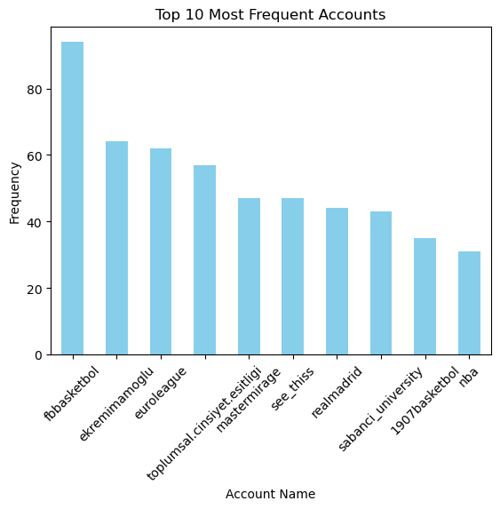

```python
import matplotlib.pyplot as plt

# Count the frequency of each account name
account_counts = accounts_liked['Account name'].value_counts()

# Select the top N accounts
top_accounts = account_counts.head(10)

# Plotting
top_accounts.plot(kind='bar', color='skyblue')
plt.title('Top 10 Most Frequent Accounts')
plt.xlabel('Account Name')
plt.ylabel('Frequency')
plt.xticks(rotation=45)
plt.show()
```

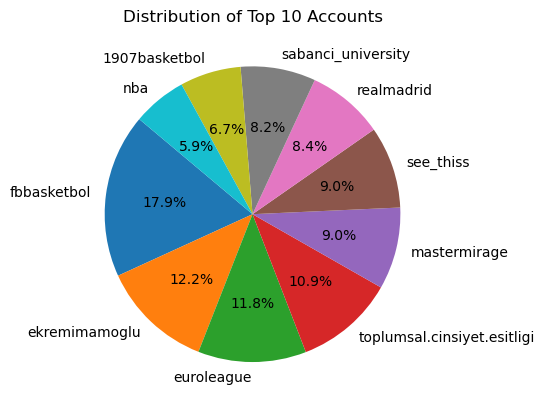

```python
# Plotting a pie chart of the distribution of top N accounts
top_accounts.plot(kind='pie', autopct='%1.1f%%', startangle=140)
plt.title('Distribution of Top 10 Accounts')
plt.ylabel('')  # Hide the y-label
plt.show()
```

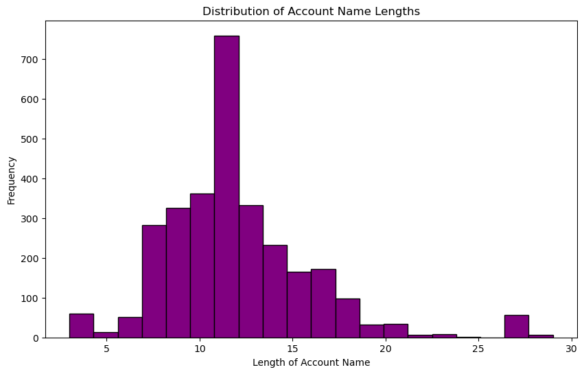

```python
# Calculate the length of each account name
accounts_liked['Name Length'] = accounts_liked['Account name'].apply(len)

# Plotting the histogram
plt.figure(figsize=(10, 6))
plt.hist(accounts_liked['Name Length'], bins=20, color='purple', edgecolor='black')
plt.title('Distribution of Account Name Lengths')
plt.xlabel('Length of Account Name')
plt.ylabel('Frequency')
plt.show()
```

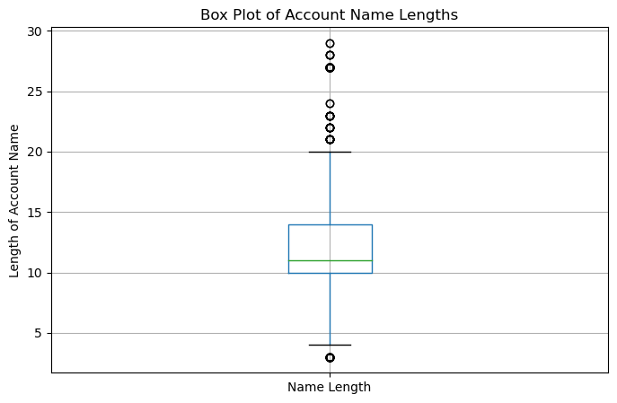

```python
# Plotting the box plot
plt.figure(figsize=(8, 5))
accounts_liked.boxplot(column=['Name Length'])
plt.title('Box Plot of Account Name Lengths')
plt.ylabel('Length of Account Name')
plt.show()
```

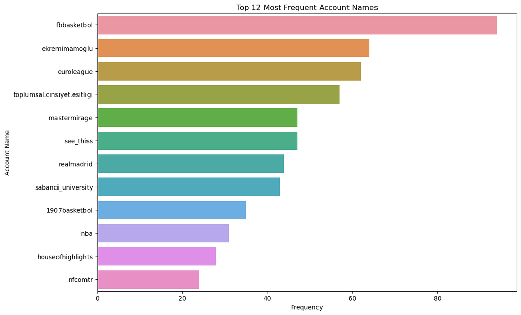

```python
import seaborn as sns

# Plotting the count plot
plt.figure(figsize=(12, 8))
sns.countplot(y='Account name', data=accounts_liked, order=accounts_liked['Account name'].value_counts().iloc[:12].index)
plt.title('Top 12 Most Frequent Account Names')
plt.xlabel('Frequency')
plt.ylabel('Account Name')
plt.show()
```

```python
coppy = accounts_liked.copy()
coppy
```

|  | Account name | Name Length |
| --- | --- | --- |
| 0 | kesfedilmemis_yol | 17 |
| 1 | yazarsesi | 9 |
| 2 | stephencurry30 | 14 |
| 3 | bitch | 5 |
| 4 | alpozakin | 9 |
| ... | ... | ... |
| 2995 | majicallynews | 13 |
| 2996 | scrimbasketball | 15 |
| 2997 | elifye.nba | 10 |
| 2998 | highonhoops | 11 |
| 2999 | solsauru | 8 |

3000 rows × 2 columns

```python
account_counts = accounts_liked['Account name'].value_counts()

# Converting it into a DataFrame
account_counts_df = account_counts.reset_index() #  is used to transform a Pandas Series into a DataFrame and adjust its structure.
account_counts_df.columns = ['Account name', 'Frequency']
account_counts_df
```

|  | Account name | Frequency |
| --- | --- | --- |
| 0 | fbbasketbol | 94 |
| 1 | ekremimamoglu | 64 |
| 2 | euroleague | 62 |
| 3 | toplumsal.cinsiyet.esitligi | 57 |
| 4 | mastermirage | 47 |
| ... | ... | ... |
| 1417 | ballislifeecs | 1 |
| 1418 | muhabbetkusubalim | 1 |
| 1419 | kral.duman16 | 1 |
| 1420 | aj_sepulveda | 1 |
| 1421 | solsauru | 1 |

1422 rows × 2 columns

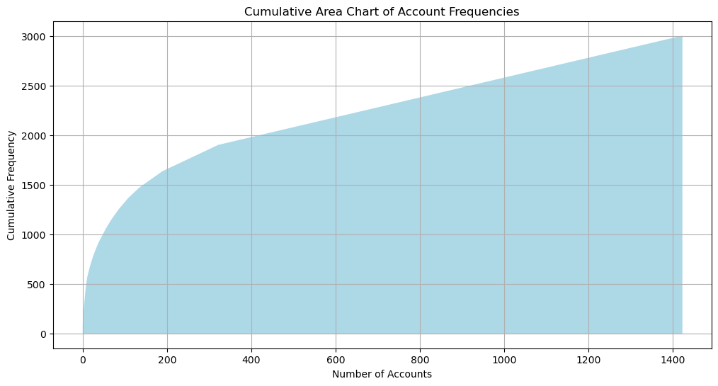

```python
cumulative_frequency = account_counts_df['Frequency'].sort_values(ascending=False).cumsum()

plt.figure(figsize=(12, 6))
plt.fill_between(range(len(cumulative_frequency)), cumulative_frequency, color='lightblue')
plt.title('Cumulative Area Chart of Account Frequencies')
plt.xlabel('Number of Accounts')
plt.ylabel('Cumulative Frequency')
plt.grid(True)
plt.show()
```

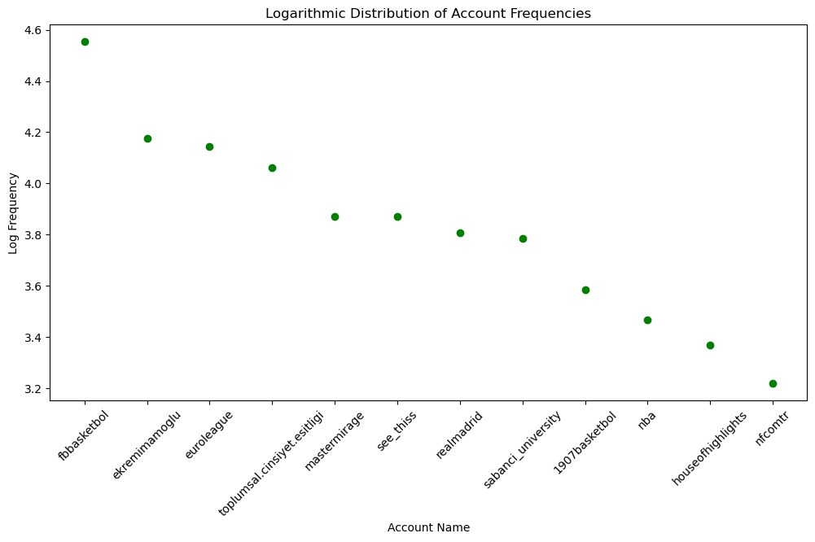

```python
import numpy as np


neww = account_counts_df.head(12) ## it does not change account_counts_df


plt.figure(figsize=(12, 6))
plt.scatter(neww['Account name'], np.log1p(neww['Frequency']), color='green')  # log1p to handle log(0)
plt.title('Logarithmic Distribution of Account Frequencies')
plt.xlabel('Account Name')
plt.ylabel('Log Frequency')
plt.xticks(rotation=45)
plt.show()
```

```python
neww
```

|  | Account name | Frequency |
| --- | --- | --- |
| 0 | fbbasketbol | 94 |
| 1 | ekremimamoglu | 64 |
| 2 | euroleague | 62 |
| 3 | toplumsal.cinsiyet.esitligi | 57 |
| 4 | mastermirage | 47 |
| 5 | see_thiss | 47 |
| 6 | realmadrid | 44 |
| 7 | sabanci_university | 43 |
| 8 | 1907basketbol | 35 |
| 9 | nba | 31 |
| 10 | houseofhighlights | 28 |
| 11 | nfcomtr | 24 |

```python
def categorize_frequency(freq):
    if freq > 50:
        return 'High'
    elif 30 < freq <= 50:
        return 'Medium'
    else:
        return 'Low'
```

```python
account_counts_df['Category'] = account_counts_df['Frequency'].apply(categorize_frequency)
```